### 空間分析 作業4

#### 地理二 B06208001 龔泓愷

> Q1：將實習所定義麥當勞的連鎖密度，建立 chainstore(d)的自訂函數，可繪製服務半徑(d) vs.麥當勞的關係圖表。

```r
library(GISTools)
library(rgdal)
library(dplyr)
library(ggplot2)
FastFood <- readOGR(dsn = "./data", layer = "Tpe_Fastfood", encoding="utf8")
Taipei_Vill <- readOGR(dsn = "./data", layer = "Taipei_Vill", encoding="utf8")
```

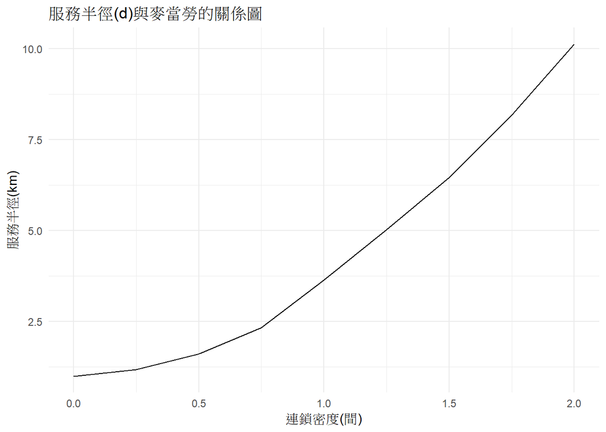

```r
#先挑出麥當勞速食店
MIC <- FastFood[FastFood$STORE == 'MIC',]

chainstore <- function(d){
  dist <- seq(0, d, 0.25) #產生半徑清單
  mean.density <- c()
  for (i in 1:length(dist)) {
    distance <- gWithinDistance(MIC, MIC, byid = T, dist = dist[i] * 10^3) #i是公里
    FF.density <- apply(distance, 1, sum) #計算連鎖密度
    mean.density[i] = mean(FF.density)
  }

  df <- data.frame(dist = dist, mean = mean.density)

  ggplot(df, aes(x = dist, y = mean)) +
    geom_line() +
    scale_x_continuous('連鎖密度(間)') + scale_y_continuous('服務半徑(km)') +
    ggtitle('服務半徑(d)與麥當勞的關係圖') +
    theme_minimal()
}
chainstore(2)
```

> Q2：比較 A區(文山+大安+中正)與 B區(信義+南港+松山) 的麥當勞連鎖密度，並利用統計檢定方法，評估 A區的平均每家麥當勞連鎖密度是否顯著高於 B區。(服務半徑(d) = 1.5 km)

```r
distance2 <-  gWithinDistance(MIC, MIC, byid = T, dist = 1500)
#先算台北市連鎖密度，再把A、B選出來，才不會漏掉該區外但在1.5公里內的麥當勞
FF.density2 <- apply(distance2, 1, sum) #自己這間麥當勞也算

MIC_A <- FF.density2[MIC$TOWN %in% c('文山區','大安區','中正區')]
MIC_B <- FF.density2[MIC$TOWN %in% c('信義區','南港區','松山區')]

mean.A <- mean(MIC_A)
mean.B <- mean(MIC_B)
sd.A <- sd(MIC_A)
sd.B <- sd(MIC_B)
n.A <- 26
n.B <- 19

paste("A區有",n.A,"間麥當勞，其連鎖密度平均為",mean.A,"連鎖密度標準差為",sd.A)
```

```
## [1] "A區有 26 間麥當勞，其連鎖密度平均為 6.92307692307692 連鎖密度標準差為 4.27011078941123"
```

```r
paste("B區有",n.B,"間麥當勞，其連鎖密度平均為",mean.B,"連鎖密度標準差為",sd.B)
```

```
## [1] "B區有 19 間麥當勞，其連鎖密度平均為 7.63157894736842 連鎖密度標準差為 3.45141720192653"
```

### 假說檢定

#### Step1

H0：A區的平均每家麥當勞連鎖密度沒有顯著高於B區  
H1：A區的平均每家麥當勞連鎖密度顯著高於B區(單尾檢定)

#### Step2

檢驗資料是否符合假說檢定要求  
皆為小樣本，因此需要看資料分布型態，大致上呈現常態分佈且無離群值

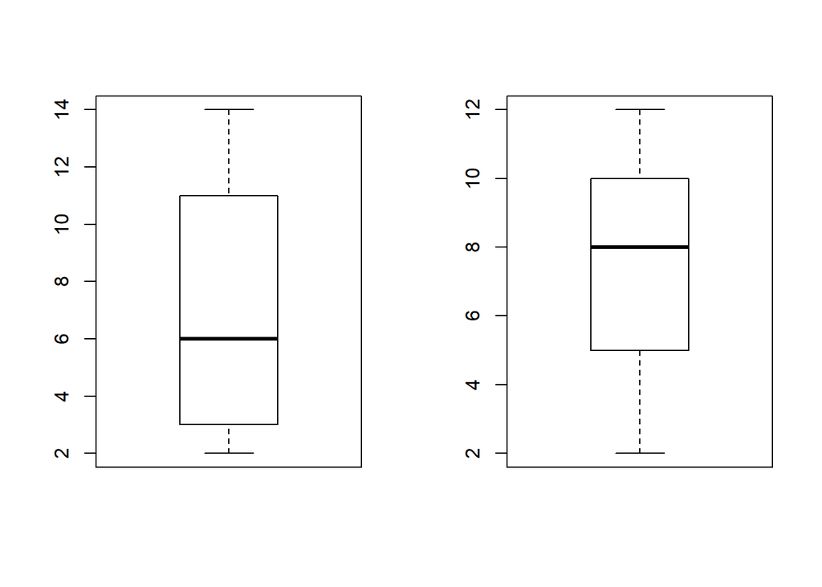

```r
#condition check
par(mfrow = c(1, 2))
boxplot(MIC_A)
boxplot(MIC_B)
```

```r
par(mfrow = c(1, 1))

#t_value
s.e. = sqrt(sd.A^2/n.A + sd.B^2/n.B);s.e.#unpooled
```

```
## [1] 1.152503
```

```r
df = min(n.A-1, n.B - 1);df#Df = Welch's Approximation or  (n1 - 1) & (n2 - 1)取小的
```

```
## [1] 18
```

```r
t_value = ((mean.A - mean.B) - 0)/s.e.;t_value
```

```
## [1] -0.6147505
```

#### Step3

採用Difference in Two Population Means的假說檢定

```r
p_value = pt(t_value, df = df, lower.tail = F);p_value#One-sided
```

```
## [1] 0.7267935
```

#### Step4

設定顯著水準(alpha) = 0.05，由於p_value > 顯著水準，所以我們無法拒絕虛無假說(H0)

#### Step5

由於我們無法拒絕虛無假說(H0)，因此我們不能下「A區的平均每家麥當勞連鎖密度顯著高於B區」的結論  
因為，我們不能拒絕「A區的平均每家麥當勞連鎖密度沒有顯著高於B區」的可能性

#### 檢查

```r
t.test(MIC_A, MIC_B ,mu = 0, alternative = "greater", paired =F, var.equal = F, conf.level = 0.95)
```

```
##
##  Welch Two Sample t-test
##
## data:  MIC_A and MIC_B
## t = -0.61475, df = 42.502, p-value = 0.729
## alternative hypothesis: true difference in means is greater than 0
## 95 percent confidence interval:
##  -2.646442       Inf
## sample estimates:
## mean of x mean of y
##  6.923077  7.631579
```